# Introdução à Programação em Python

## Funções

Na aula anterior utilizamos algumas funções para realizar certas operações além das fundamentais.

```python
import math
x = input("Entre com um valor: ")
y = math.log(x)
print y
```

```
Entre com um valor: 2.0
0.69314718056
```

Conceitualmente uma função é uma sequência de operações que realiza uma computação. Ou, um algoritmo que pode ser executado utilizando um nome.

Nos exemplos acima a função `input()` pode receber zero ou um parâmetro e devolve um valor, aquele digitado pelo usuário.

A função `math.log()` recebe um valor numérico e retorna um outro valor numérico, referente ao logarítmo da entrada.

Além de atribuir o(s) valore(s) de saída da função para variáveis, podemos também fazer a composição de funções. Digamos que queremos obter o valor de:

$$ cos(\frac{x}{\sqrt{2.0}})$$

Nesse caso temos que o valor de x é dividido pelo valor da raíz de 2.0 para então calcularmos o cosseno do resultado.

```python
x = input("Entre com um valor: ")
print math.cos( x/math.sqrt(2.0) )
```

```
Entre com um valor: 3.14
-0.604803392463
```

Além das funções existentes, o Python permite criar novas funções que serão úteis ao longo do seu programa.

Para criar uma função é preciso definir:

- um nome
- o que ele receberá de entrada
- o que ele retornará de saída

Digamos que precisamos saber os valores da função $f(x) = 3x^2 + 2x - 10$ para diversos valores de $x$. Sabemos que a biblioteca `math` não tem tal função.

Vamos criar essa função no Python.

```python
# o nome da minha função é minhaEq
def minhaEq(x):   # ela recebe um valor x de entrada
    return 3*x**2 + 2*x - 10  # retorna o valor da eq. do segundo grau
```

O comando `def minhaEQ(x):` indica que criaremos uma função.de nome *minhaEQ* e que receberá a entrada *x* definida dentro dos parênteses. O dois pontos (:) indica que a definição da função será escrita em seguida.

A linha seguinte utiliza a instrução `return` para dizer que o valor da expressão a seguir será retornada para quem chamou a função.

NOTA: para o Python saber quais instruções pertencem a função ele verifica o alinhamento da instrução em relação a declaração da função. Utilizamos espaços para alinhar essas instruções, como convenção múltiplos de 4.

[figure not shown]

```python
# vamos criar novamente a função
def minhaEq(x):
    return 3*x**2 + 2*x - 10

print minhaEq(10)  # ele retorna para a função print o valor de 3*10**2 + 2*10 - 10
print minhaEq(5)
print minhaEq(1)
```

```
310
75
-5
```

As funções podem ter múltiplas variáveis se necessário e múltiplas instruções, desde que elas estejam alinhadas:

```python
def eqGenerica(a,b,c,x):
    # as próximas duas linhas tem o mesmo alinhamento
     y = a*x**2 + b*x + c
     return y

print eqGenerica(3,2,-10,10)
```

```
310
```

Vamos criar uma função que recebe duas variáveis, x e y, e retorna a média aritmética entre elas.

```python
# Exercício


print media(5,3)
print media(2,10)
```

Uma função pode retornar mais do que uma variável também se necessário:

```python
# faz uma divisão de inteiros, retornando
# o quociente e o resto
def divideInt(x,y):
    q = x/y # quociente
    r = x%y # resto
    return q, r

q,r = divideInt(10,3)
print "10 dividido por 3 é igual a ", q, "e sobra", r
```

```
10 dividido por 3 é igual a  3 e sobra 1
```

E ela pode retornar qualquer um dos tipos que vimos até agora, até mesmo retornar uma função:

```python
def geraEq(a,b,c):
    # observem o alinhamento
    # vou criar uma função que recebe x como entrada
    # e retorna a eq. do segundo grau definida por
    # a,b,c
    def eq2(x):
        return a*x**2 + b*x + c
    # retorno minha função criada
    return eq2

fx = geraEq(3,2,-10)
print fx(10)
```

```
310
```

Vamos praticar com alguns exercícios!

1) Crie uma função que retorne uma função que dê os valores das funções seno e cosseno dados por:

```
f(x) = A . sin(2*pi*freq*x + phi)
f(x) = A . cos(2*pi*freq*x + phi)
```

sendo:

amplitude A, a frequencia freq,e a fase phi definidos pelo usuário, o valor de pi pode ser obtido usando `math.pi`

```python
import math

def minhaEq(A,freq,phi):
    # complete o seu código abaixo seguindo o alinhamento
    def SenoCos(x):

        return seno, cos
    # fim do código do aluno
    return SenoCos

minhaOnda = minhaEq(10,1,2)
print minhaOnda(10) # resultado deve ser 9.09, -4.16
```

```
(9.092974268256826, -4.161468365471402)
```

2) Crie uma função que retorne a tangente da função criada.

Repare que podemos utilizar a função minhaOnda(x) dentro da nossa função tangente(x)!

```python
def tangente(x):
    # escreva o seu código abaixo

    # fim do código do aluno
    return sen/cos

tanX = tangente(10)
print tanX # resultado deve ser -2.18
```

```
-2.18503986326
```

Vamos revisitar nosso programa de plotagem de gráfico da aula passada.

Como precisávamos das variáveis x e y=f(x) para plotar os pontos, tinhamos que construir as duas listas digitando cada um dos valores de x e f(x).

```python
%pylab nbagg
x = [-5,-4,-3,-2,-1,0,1,2,3,4,5]
y = [25,16,9,4,1,0,1,4,9,16,25]
#plot(x,y)
```

Para construir a lista f(x) o Python tem a função

`map( f, lista )`

ela recebe duas entradas: uma função e uma lista de valores.

A função map aplica a função f em cada elemento de lista e retorna a lista com os valores transformados.

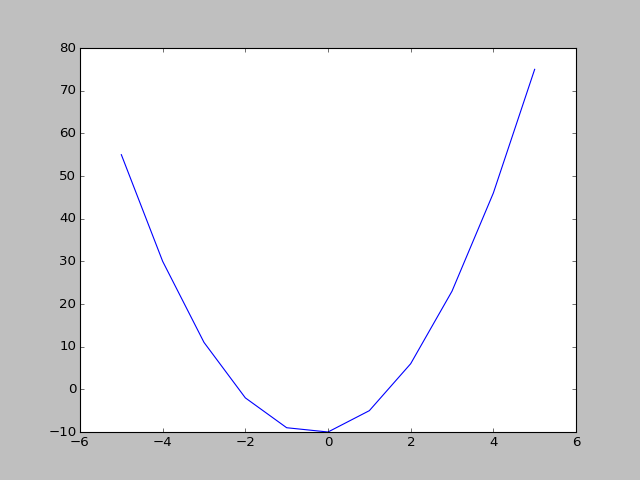

```python
%pylab nbagg
# vamos usar a função que criamos anteriormente
fx = geraEq(3,2,-10)
x = [-5,-4,-3,-2,-1,0,1,2,3,4,5]
y = map(fx,x) # equivalente a [fx(-5),fx(-4),,...]
plot(x,y)
```

Quando utilizamos o `pylab` temos também a função `frange(inicio, fim, passo)` que gera uma lista de valores entre *inicio* e *fim* de *passo* em *passo*.

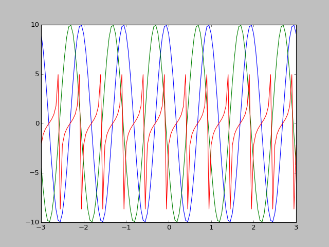

```python
%pylab nbagg
x = frange(-3,3,0.05)  # gera [-3, -2.95, -2.9, ...]
y = map(minhaOnda,x) # equivalente a [minhaOnda(-3),minhaOnda(-2.95),minhaOnda(-2.9),,...]
plot(x,y)
y = map(tangente,x)
plot(x,y)
```

## Opcional

O IPython permite criar um gráfico interativo utilizando a função `interact`.

O primeiro parâmetro de `interact` é uma função que faz o trabalho de plotar o gráfico. Os próximos parâmetros são a faixa de valores que cada parâmetro da função pode ter. Ex.:

`A = (1,5,2)`

o parâmetro A pode ter valores de 1 a 5, aumentando de 2 em 2: [1,3,5]

```
<function __main__.plotaSenCosTan>
```

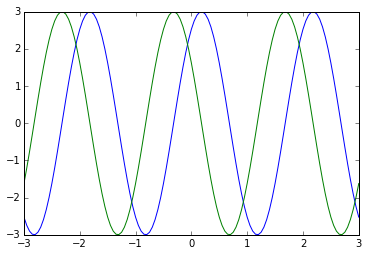

```python
# temos que usar a opcao inline
%pylab inline
from IPython.html.widgets import interact

def plotaSenCosTan(A, freq, fase):
    minhaOnda = minhaEq(A,freq,fase)
    x = frange(-3,3,0.05)  # gera a lista [-3, -2.95, -2.9, -2.85,...,3]
    y = map(minhaOnda,x) # equivalente a [minhaOnda(-3),minhaOnda(-2.95),minhaOnda(-2.9),,...]
    fig = plot(x,y)
    return fig

interact(plotaSenCosTan, A = (1,5,2), freq=(0.25,1.0,0.25), fase=(1,10,5))
```

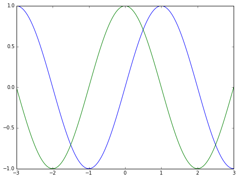

**A:**  
**fase:**  
**freq:**

```python
# para o slide
from ipywidgets import StaticInteract, RangeWidget, RadioWidget

def plotaSenCosTan(A, freq, fase):
    minhaOnda = minhaEq(A,freq,fase)
    x = frange(-3,3,0.05)  # gera a lista [-3, -2.95, -2.9, -2.85,...,3]
    y = map(minhaOnda,x) # equivalente a [minhaOnda(-3),minhaOnda(-2.95),minhaOnda(-2.9),,...]
    fig, ax = subplots(figsize=(8, 6))
    ax.plot(x,y)
    return fig

StaticInteract(plotaSenCosTan,
               A=RangeWidget(1,5,2),
               freq=RangeWidget(0.25,1.0,0.25),
               fase=RangeWidget(0,10,5))
```